# Project: Investigate IMDB-Movie Dataset

- Introduction
- Data Wrangling
- Exploratory Data Analysis
- Conclusions

## Introduction

### For this exercise, I am using the tmdb-movie dataset. In this dataset, there are list of movies between 1960 and 2015 with their box office collections, cast, genres, and many other details. Being a movie-buff, I am really excited to be working on this dataset.

- Plot a histogram of Average Votes and see the distribution.
- Find the biggest box office hits by inflation-adjusted Profit every year.
- Find correlation between various fields to see if there is anything that comes out of it.
- How does the Movie runtime changing over time? (Does any specific genre contributes to the shorter/longer runtime?).
- Explore the Keywords field in the dataset to find patterns.
- Try to find a correlation between budget and revenue every decade.
- Find out the Top 5 Movie Genres by Gross Profit every Decade.

```python
#importing python libraries
import math
import numpy as np
import pandas as pd
import matplotlib
import matplotlib.pyplot as plt
%matplotlib inline
import seaborn as sns
```

## Data Wrangling

```python
#load data into dataframe
df=pd.read_csv('C:\\Users\\puspa\\datafiles\\tmdb-movies.csv',
               index_col='id')
```

```python
#inpecting the top two rows
df.head(2)
```

| id | imdb_id | popularity | budget | revenue | original_title | cast | homepage | director | tagline | keywords | overview | runtime | genres | production_companies | release_date | vote_count | vote_average | release_year | budget_adj | revenue_adj |
| --- | --- | --- | --- | --- | --- | --- | --- | --- | --- | --- | --- | --- | --- | --- | --- | --- | --- | --- | --- | --- |
| 135397 | tt0369610 | 32.985763 | 150000000 | 1513528810 | Jurassic World | Chris Pratt\|Bryce Dallas Howard\|Irrfan Khan\|Vi... | http://www.jurassicworld.com/ | Colin Trevorrow | The park is open. | monster\|dna\|tyrannosaurus rex\|velociraptor\|island | Twenty-two years after the events of Jurassic ... | 124 | Action\|Adventure\|Science Fiction\|Thriller | Universal Studios\|Amblin Entertainment\|Legenda... | 6/9/15 | 5562 | 6.5 | 2015 | 1.379999e+08 | 1.392446e+09 |
| 76341 | tt1392190 | 28.419936 | 150000000 | 378436354 | Mad Max: Fury Road | Tom Hardy\|Charlize Theron\|Hugh Keays-Byrne\|Nic... | http://www.madmaxmovie.com/ | George Miller | What a Lovely Day. | future\|chase\|post-apocalyptic\|dystopia\|australia | An apocalyptic story set in the furthest reach... | 120 | Action\|Adventure\|Science Fiction\|Thriller | Village Roadshow Pictures\|Kennedy Miller Produ... | 5/13/15 | 6185 | 7.1 | 2015 | 1.379999e+08 | 3.481613e+08 |

```python
df.dtypes
```

```
imdb_id                  object
popularity              float64
budget                    int64
revenue                   int64
original_title           object
cast                     object
homepage                 object
director                 object
tagline                  object
keywords                 object
overview                 object
runtime                   int64
genres                   object
production_companies     object
release_date             object
vote_count                int64
vote_average            float64
release_year              int64
budget_adj              float64
revenue_adj             float64
dtype: object
```

### Quick observations and fix in earlier steps:

##### Release data was in object format, converted it to a date

##### Genres , Production_Companies are the fields with multiple values concatenated. It needs to be splitted to be able to plot metrics by genres

```python
df['release_date']=pd.to_datetime(df.release_date)
df.dtypes
```

```
imdb_id                         object
popularity                     float64
budget                           int64
revenue                          int64
original_title                  object
cast                            object
homepage                        object
director                        object
tagline                         object
keywords                        object
overview                        object
runtime                          int64
genres                          object
production_companies            object
release_date            datetime64[ns]
vote_count                       int64
vote_average                   float64
release_year                     int64
budget_adj                     float64
revenue_adj                    float64
dtype: object
```

```python
#add profit & profit(adjusted) field (Gross Profit)

df['profit_adj'] = df['revenue_adj']- df['budget_adj']
df['profit'] = df['revenue']- df['budget']
```

```python
#remove rows with null ID or zero Budget and Revenue

df.where((df['imdb_id']!='') & (df['budget_adj']>=1.0) &  (df['revenue_adj']>=1.0))
df.dropna()
```

| id | imdb_id | popularity | budget | revenue | original_title | cast | homepage | director | tagline | keywords | ... | genres | production_companies | release_date | vote_count | vote_average | release_year | budget_adj | revenue_adj | profit_adj | profit |
| --- | --- | --- | --- | --- | --- | --- | --- | --- | --- | --- | --- | --- | --- | --- | --- | --- | --- | --- | --- | --- | --- |
| 135397 | tt0369610 | 32.985763 | 150000000 | 1513528810 | Jurassic World | Chris Pratt\|Bryce Dallas Howard\|Irrfan Khan\|Vi... | http://www.jurassicworld.com/ | Colin Trevorrow | The park is open. | monster\|dna\|tyrannosaurus rex\|velociraptor\|island | ... | Action\|Adventure\|Science Fiction\|Thriller | Universal Studios\|Amblin Entertainment\|Legenda... | 2015-06-09 | 5562 | 6.5 | 2015 | 1.379999e+08 | 1.392446e+09 | 1.254446e+09 | 1363528810 |
| 76341 | tt1392190 | 28.419936 | 150000000 | 378436354 | Mad Max: Fury Road | Tom Hardy\|Charlize Theron\|Hugh Keays-Byrne\|Nic... | http://www.madmaxmovie.com/ | George Miller | What a Lovely Day. | future\|chase\|post-apocalyptic\|dystopia\|australia | ... | Action\|Adventure\|Science Fiction\|Thriller | Village Roadshow Pictures\|Kennedy Miller Produ... | 2015-05-13 | 6185 | 7.1 | 2015 | 1.379999e+08 | 3.481613e+08 | 2.101614e+08 | 228436354 |
| 262500 | tt2908446 | 13.112507 | 110000000 | 295238201 | Insurgent | Shailene Woodley\|Theo James\|Kate Winslet\|Ansel... | http://www.thedivergentseries.movie/#insurgent | Robert Schwentke | One Choice Can Destroy You | based on novel\|revolution\|dystopia\|sequel\|dyst... | ... | Adventure\|Science Fiction\|Thriller | Summit Entertainment\|Mandeville Films\|Red Wago... | 2015-03-18 | 2480 | 6.3 | 2015 | 1.012000e+08 | 2.716190e+08 | 1.704191e+08 | 185238201 |
| 140607 | tt2488496 | 11.173104 | 200000000 | 2068178225 | Star Wars: The Force Awakens | Harrison Ford\|Mark Hamill\|Carrie Fisher\|Adam D... | http://www.starwars.com/films/star-wars-episod... | J.J. Abrams | Every generation has a story. | android\|spaceship\|jedi\|space opera\|3d | ... | Action\|Adventure\|Science Fiction\|Fantasy | Lucasfilm\|Truenorth Productions\|Bad Robot | 2015-12-15 | 5292 | 7.5 | 2015 | 1.839999e+08 | 1.902723e+09 | 1.718723e+09 | 1868178225 |
| 168259 | tt2820852 | 9.335014 | 190000000 | 1506249360 | Furious 7 | Vin Diesel\|Paul Walker\|Jason Statham\|Michelle ... | http://www.furious7.com/ | James Wan | Vengeance Hits Home | car race\|speed\|revenge\|suspense\|car | ... | Action\|Crime\|Thriller | Universal Pictures\|Original Film\|Media Rights ... | 2015-04-01 | 2947 | 7.3 | 2015 | 1.747999e+08 | 1.385749e+09 | 1.210949e+09 | 1316249360 |
| ... | ... | ... | ... | ... | ... | ... | ... | ... | ... | ... | ... | ... | ... | ... | ... | ... | ... | ... | ... | ... | ... |
| 668 | tt0064757 | 1.778746 | 7000000 | 81974493 | On Her Majesty's Secret Service | George Lazenby\|Diana Rigg\|Telly Savalas\|Gabrie... | http://www.mgm.com/view/movie/1411/On-Her-Maje... | Peter R. Hunt | Far up! Far out! Far more! James Bond 007 is b... | london\|suicide\|england\|switzerland\|secret iden... | ... | Adventure\|Action\|Thriller | Eon Productions\|Metro-Goldwyn-Mayer (MGM)\|Danjaq | 2069-12-12 | 258 | 6.4 | 1969 | 4.160985e+07 | 4.872780e+08 | 4.456682e+08 | 74974493 |
| 948 | tt0077651 | 1.198849 | 300000 | 70000000 | Halloween | Donald Pleasence\|Jamie Lee Curtis\|P.J. Soles\|N... | http://www.theofficialjohncarpenter.com/hallow... | John Carpenter | The Night HE Came Home! | female nudity\|nudity\|mask\|babysitter\|halloween | ... | Horror\|Thriller | Compass International Pictures\|Falcon Internat... | 1978-10-25 | 522 | 7.3 | 1978 | 1.002810e+06 | 2.339890e+08 | 2.329862e+08 | 69700000 |
| 8469 | tt0077975 | 1.157930 | 2700000 | 141000000 | Animal House | John Belushi\|Tim Matheson\|John Vernon\|Verna Bl... | http://www.animalhouse.com/ | John Landis | It was the Deltas against the rules... the rul... | female nudity\|sex\|nudity\|collage\|fraternity | ... | Comedy | Universal Pictures\|Oregon Film Factory\|Stage I... | 1978-07-27 | 230 | 6.7 | 1978 | 9.025292e+06 | 4.713208e+08 | 4.622955e+08 | 138300000 |
| 13963 | tt0077838 | 0.064029 | 0 | 321952 | The Last Waltz | Robbie Robertson\|Rick Danko\|Levon Helm\|Richard... | http://www.mgm.com/#/our-titles/1092/The-Last-... | Martin Scorsese | It Started as a Concert. It Became a Celebration. | 1970s\|music | ... | Documentary\|Music | FM Productions\|Last Waltz Inc. | 1978-05-01 | 33 | 8.0 | 1978 | 0.000000e+00 | 1.076189e+06 | 1.076189e+06 | 321952 |
| 16214 | tt0077696 | 0.044675 | 0 | 78000000 | Hooper | Burt Reynolds\|Robert Klein\|Adam West\|Jan-Micha... | http://en.wikipedia.org/wiki/Hooper_(film) | Hal Needham | The greatest stuntman alive! | stuntman\|hollywood | ... | Action\|Comedy | Warner Bros. | 1978-07-28 | 13 | 6.0 | 1978 | 0.000000e+00 | 2.607307e+08 | 2.607307e+08 | 78000000 |

1992 rows × 22 columns

```python
#drop any duplicate record
df.drop_duplicates(subset ="original_title",
                     keep = False, inplace = True)
```

```python
# Make the metrics in Millions format for easy display and readability

cols= ['budget_adj','revenue_adj','profit_adj','budget','revenue','profit']

df[cols] = round(df[cols]/1000000,0)

df.head()
```

| id | imdb_id | popularity | budget | revenue | original_title | cast | homepage | director | tagline | keywords | ... | genres | production_companies | release_date | vote_count | vote_average | release_year | budget_adj | revenue_adj | profit_adj | profit |
| --- | --- | --- | --- | --- | --- | --- | --- | --- | --- | --- | --- | --- | --- | --- | --- | --- | --- | --- | --- | --- | --- |
| 135397 | tt0369610 | 32.985763 | 150.0 | 1514.0 | Jurassic World | Chris Pratt\|Bryce Dallas Howard\|Irrfan Khan\|Vi... | http://www.jurassicworld.com/ | Colin Trevorrow | The park is open. | monster\|dna\|tyrannosaurus rex\|velociraptor\|island | ... | Action\|Adventure\|Science Fiction\|Thriller | Universal Studios\|Amblin Entertainment\|Legenda... | 2015-06-09 | 5562 | 6.5 | 2015 | 138.0 | 1392.0 | 1254.0 | 1364.0 |
| 76341 | tt1392190 | 28.419936 | 150.0 | 378.0 | Mad Max: Fury Road | Tom Hardy\|Charlize Theron\|Hugh Keays-Byrne\|Nic... | http://www.madmaxmovie.com/ | George Miller | What a Lovely Day. | future\|chase\|post-apocalyptic\|dystopia\|australia | ... | Action\|Adventure\|Science Fiction\|Thriller | Village Roadshow Pictures\|Kennedy Miller Produ... | 2015-05-13 | 6185 | 7.1 | 2015 | 138.0 | 348.0 | 210.0 | 228.0 |
| 262500 | tt2908446 | 13.112507 | 110.0 | 295.0 | Insurgent | Shailene Woodley\|Theo James\|Kate Winslet\|Ansel... | http://www.thedivergentseries.movie/#insurgent | Robert Schwentke | One Choice Can Destroy You | based on novel\|revolution\|dystopia\|sequel\|dyst... | ... | Adventure\|Science Fiction\|Thriller | Summit Entertainment\|Mandeville Films\|Red Wago... | 2015-03-18 | 2480 | 6.3 | 2015 | 101.0 | 272.0 | 170.0 | 185.0 |
| 140607 | tt2488496 | 11.173104 | 200.0 | 2068.0 | Star Wars: The Force Awakens | Harrison Ford\|Mark Hamill\|Carrie Fisher\|Adam D... | http://www.starwars.com/films/star-wars-episod... | J.J. Abrams | Every generation has a story. | android\|spaceship\|jedi\|space opera\|3d | ... | Action\|Adventure\|Science Fiction\|Fantasy | Lucasfilm\|Truenorth Productions\|Bad Robot | 2015-12-15 | 5292 | 7.5 | 2015 | 184.0 | 1903.0 | 1719.0 | 1868.0 |
| 168259 | tt2820852 | 9.335014 | 190.0 | 1506.0 | Furious 7 | Vin Diesel\|Paul Walker\|Jason Statham\|Michelle ... | http://www.furious7.com/ | James Wan | Vengeance Hits Home | car race\|speed\|revenge\|suspense\|car | ... | Action\|Crime\|Thriller | Universal Pictures\|Original Film\|Media Rights ... | 2015-04-01 | 2947 | 7.3 | 2015 | 175.0 | 1386.0 | 1211.0 | 1316.0 |

5 rows × 22 columns

```python
#Split the Genres into its own category

genres = df['genres'].str.split('|',expand=True).stack().to_frame(name='genre')
genres.head(3)
```

| id |  | genre |
| --- | --- | --- |
| 135397 | 0 | Action |
|  | 1 | Adventure |
|  | 2 | Science Fiction |

```python
#keep the index so that it can be joined back to the main dataframe "df"

genres.index = genres.index.droplevel(1)
genres.head(2)
```

| id | genre |
| --- | --- |
| 135397 | Action |
| 135397 | Adventure |

## Exploratory Data Analysis

### 1) Plot a histogram of Average Votes and see the distribution.

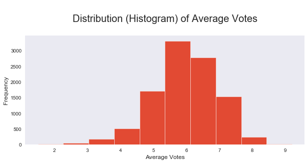

```python
f, ax = plt.subplots(figsize=(10, 4))

# Plot top Movies
df["vote_average"].hist(bins=10)

#sns.barplot(x="profit_adj", y='Title-year', data=Top_movies_Every_Year.sort_values('profit_adj',ascending=False),
 #           label="Gross Profit")

#formatting and labels
ax.set_title('\nDistribution (Histogram) of Average Votes\n',fontsize=20)
ax.set(xlabel="Average Votes", ylabel="Frequency")
sns.despine(left=True, bottom=True, trim=True)
plt.grid(False)
```

#### Average votes seems to be nicely distributed in the dataset. higher percentage of the movies in the dataset have a rating between 5 to 7, which means that most of the movies made between 1965 and 2015 have above average or better poularity.

### 2) Find the biggest box office hits by inflation-adjusted Profit every year.

```python
Movie_profit_every_year=df.groupby(['release_year','original_title'], as_index=False).agg({'profit_adj':'sum'})
Movie_profit_every_year.head(5)


Top_movies_Every_Year = Movie_profit_every_year[['release_year','original_title','profit_adj']].sort_values(['release_year','profit_adj'],ascending=False).groupby('release_year',sort=True).head(1)


Top_movies_Every_Year.head(5)
```

|  | release_year | original_title | profit_adj |
| --- | --- | --- | --- |
| 10106 | 2015 | Star Wars: The Force Awakens | 1719.0 |
| 9562 | 2014 | The Hobbit: The Battle of the Five Armies | 649.0 |
| 8647 | 2013 | Iron Man 3 | 950.0 |
| 8216 | 2012 | Skyfall | 863.0 |
| 7482 | 2011 | Harry Potter and the Deathly Hallows: Part 2 | 1166.0 |

### Function

```python
# Convert the big numebrs to a human readable format (Millions, Billions and so on)

def human_format(num):
    magnitude = 0
    while abs(num) >= 1000:
        magnitude += 1
        num /= 1000.0
    # add more suffixes if you need them
    return '%.2f%s' % (num, ['', 'K', 'M', 'B', 'T', 'P'][magnitude])
```

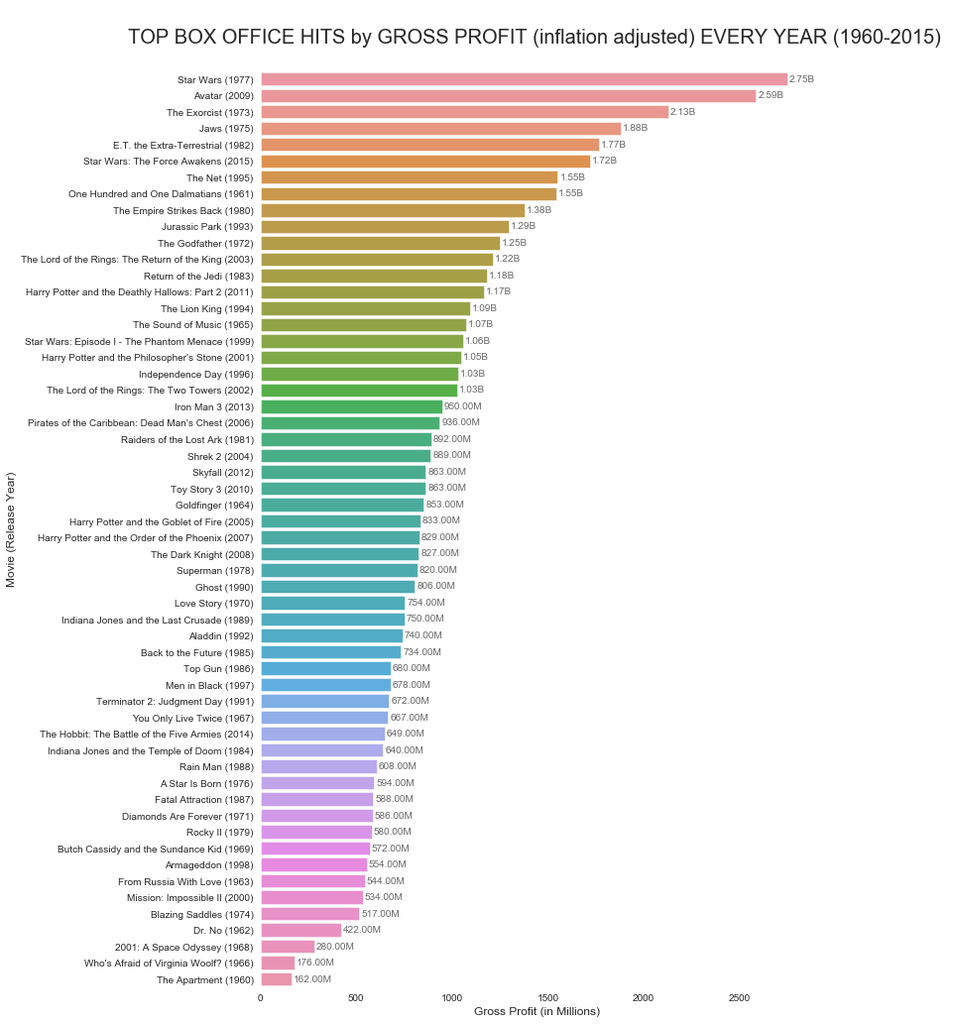

```python
Top_movies_Every_Year['Title-year'] = Top_movies_Every_Year['original_title']+" ("+ (Top_movies_Every_Year['release_year']).astype(str)+")"

# Initialize the matplotlib figure
f, ax = plt.subplots(figsize=(10, 17))


# Plot top Movies
sns.barplot(x="profit_adj", y='Title-year', data=Top_movies_Every_Year.sort_values('profit_adj',ascending=False),
            label="Gross Profit")

#formatting and labels
ax.set_title('\nTOP BOX OFFICE HITS by GROSS PROFIT (inflation adjusted) EVERY YEAR (1960-2015) \n',fontsize=20)
ax.set(xlabel="Gross Profit (in Millions)", ylabel="Movie (Release Year)")
sns.despine(left=True, bottom=True)

totals = []

# find the values and append to list
for i in ax.patches:
    totals.append(i.get_width())

# set individual bar lables using above list
total = sum(totals)

# set individual bar lables using above list
for i in ax.patches:
    # get_width pulls left or right; get_y pushes up or down
    ax.text(i.get_width()+10, i.get_y()+.55, \
            (human_format(i.get_width()*1000000)), fontsize=10,    #used the user_function to format the numbers

color='dimgrey')
```

#### The Bar graph shows the list of movies that generated the most Gross profit every year. 1977 movie Star wars seems to be on the top of the list amond all the yearly top-grossers. 2009 movie Avatar is at the second place.

##### *This is assuming that we have all the movies between 1960-2015 in the data set and also we are looking the Inflation adjusted gross profit.

### 3) Find correlation between various fields to see if there is anything that comes out.

```python
df_corr = df.corr(method='pearson')
```

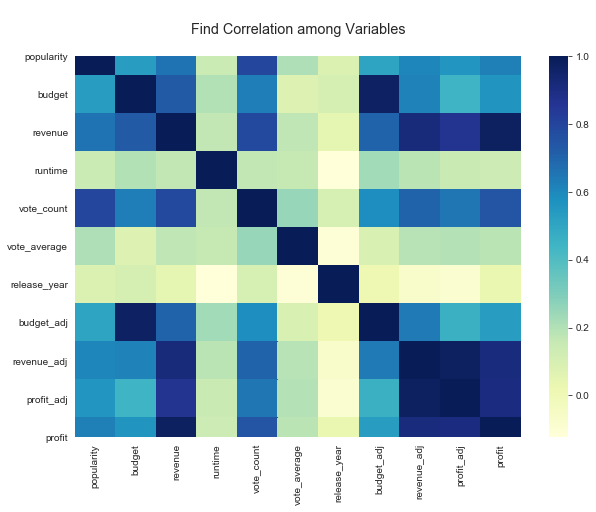

```python
ax = plt.subplots(figsize=(10, 7))
sns.heatmap(df_corr, cmap="YlGnBu")
plt.title("\nFind Correlation among Variables\n")
```

##### One this that sticks out on this is release year seem to be negatively correlated to Run time. It would be interesting to see if there is a story there.

#### Also, Budget and Revenue seem t be highly correlated, which suggests that higer budget movies generate more revenues.

### 4) How does the Movie runtime changing over time? (Does any specific genre contributes to the shorter/longer runtime?).

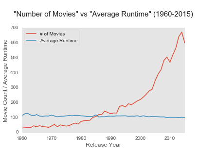

```python
df_movie_count_runtime=df.groupby('release_year').agg({'imdb_id':'size', 'runtime':'mean'})\
.rename(columns = {'imdb_id': '# of Movies', 'runtime': 'Average Runtime'})

plt.style.use('ggplot')

# Plot top Movies
df_movie_count_runtime.groupby(['release_year']).sum().plot.line()


#formatting and labels
plt.title('\n "Number of Movies" vs "Average Runtime" (1960-2015) \n',fontsize=15)


plt.xlabel('Release Year')
plt.ylabel('Movie Count / Average Runtime')
plt.grid(False)
```

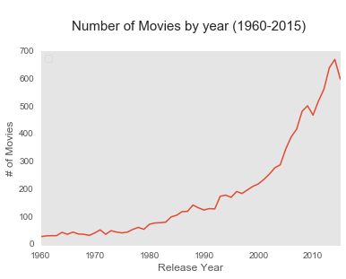

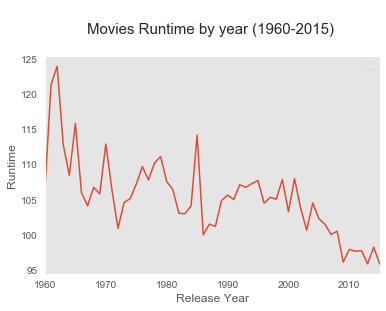

```python
df[['release_year','imdb_id']].groupby(['release_year']).count().plot.line()

plt.style.use('ggplot')

plt.title('\nNumber of Movies by year (1960-2015) \n',fontsize=15)
plt.xlabel('Release Year')
plt.ylabel('# of Movies')
plt.legend('')
plt.grid(False)

df[['release_year','runtime']].groupby(['release_year']).mean().plot.line()

plt.title('\nMovies Runtime by year (1960-2015) \n',fontsize=15)
plt.xlabel('Release Year')
plt.ylabel('Runtime')
plt.legend('')
plt.grid(False)
```

### From the above line charts, it looks like Average Run time is trending down from 1960 to 2015.

#### There could be many reasons for that but, I think many short movies like, Documentaries, thrillers etc. being made in recent years could be contributing towards the downward trend. So, it would be interesting to analyze the trend by each genres.

```python
#Movie runtime by Genres each year
Movie_runtime_by_genres_yearly = pd.merge(genres, df[['release_year','runtime']] , left_on='id', right_on='id', how='left')

#Average runtime by Genres each year

Movie_avg_runtime_by_genres_yearly=Movie_runtime_by_genres_yearly.groupby(['genre','release_year'], as_index=False).mean()

Movie_avg_runtime_by_genres_yearly.head(5)
```

|  | genre | release_year | runtime |
| --- | --- | --- | --- |
| 0 | Action | 1960 | 122.000 |
| 1 | Action | 1961 | 134.000 |
| 2 | Action | 1962 | 125.375 |
| 3 | Action | 1963 | 136.000 |
| 4 | Action | 1964 | 128.750 |

#### Upon investigating, I found that there are a few movies with runtime of more than 500 minutes or close to 0 minutes. Most o fthe seem to be Historical TV series or Animated series.

#### I've filtered those outliers from the dataset to be able to plot a smooth line.

```python
Movie_runtime_by_genres_yearly = Movie_runtime_by_genres_yearly.where((Movie_runtime_by_genres_yearly['runtime']<200)\
                                     & (Movie_runtime_by_genres_yearly['runtime']>5))

Movie_avg_runtime_by_genres_yearly=Movie_runtime_by_genres_yearly.groupby(['genre','release_year'], as_index=False).mean()

Movie_avg_runtime_by_genres_yearly.head(5)
```

|  | genre | release_year | runtime |
| --- | --- | --- | --- |
| 0 | Action | 1960.0 | 104.800 |
| 1 | Action | 1961.0 | 134.000 |
| 2 | Action | 1962.0 | 125.375 |
| 3 | Action | 1963.0 | 136.000 |
| 4 | Action | 1964.0 | 128.750 |

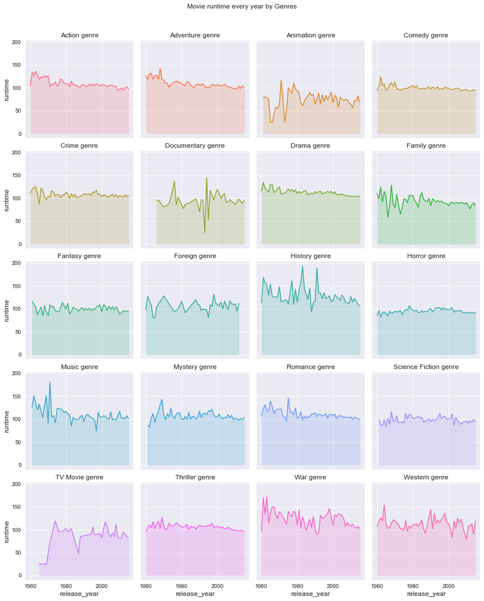

```python
# Create a grid : initialize it
g = sns.FacetGrid(Movie_avg_runtime_by_genres_yearly, col='genre', hue='genre', col_wrap=4, )

# Add the line over the area with the plot function
g = g.map(plt.plot, 'release_year', 'runtime')

# Fill the area with fill_between
g = g.map(plt.fill_between, 'release_year', 'runtime', alpha=0.2).set_titles("{col_name} genre")

# Add a title for the whole ploT
plt.subplots_adjust(top=0.92)
g = g.fig.suptitle('Movie runtime every year by Genres')
sns.despine(left=True, bottom=True, trim=True)
plt.show()
```

### 5) Explore the Keyward field in the dataset to find patterns.

##### a Wordcloud would be a great way to find promintent keywords

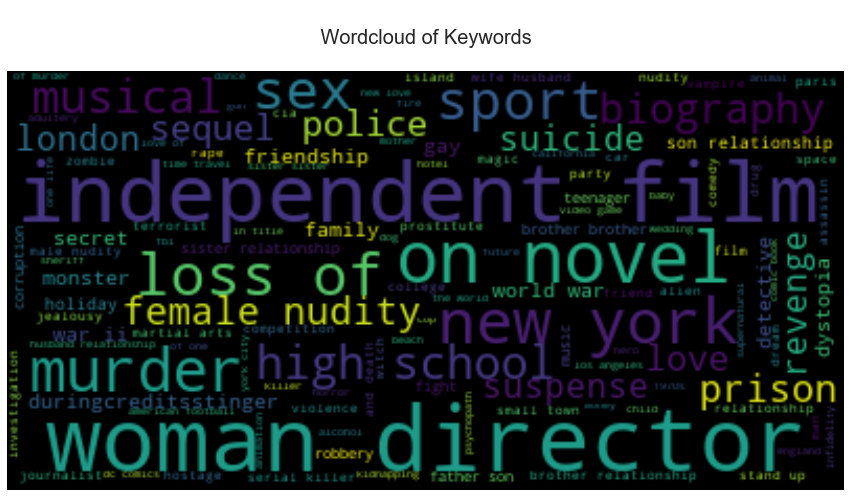

```python
from wordcloud import WordCloud

wordcloud = WordCloud(stopwords = ("based","on","based on")).generate(' '.join(df['keywords'].fillna('')))
plt.figure( figsize=(15,8) )
plt.imshow(wordcloud, interpolation="bilinear") #"Bilinear makes the workds smoother"
plt.axis("off")
plt.title("\n Wordcloud of Keywords \n",fontsize=20)
plt.show()
```

##### The top Keywards suggest that there are many Independent fims made between 1965 and 2015. Also, the wordcloud suggests thats there are many movies made by women directors, movies based on Novels and New Your city appears prominately in the dataset.

### 6) Try to find a correlation between budget and revenue every decade.

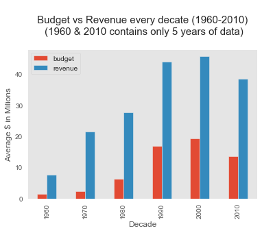

```python
df["decade"] = (df["release_year"]//10)*10

movie_every_decade = df[['decade','original_title','budget','revenue']]

movie_every_decade.groupby('decade').mean().plot.bar()

#formatting and labels
plt.title('\n Budget vs Revenue every decate (1960-2010) \n (1960 & 2010 contains only 5 years of data)\n',fontsize=15)


plt.xlabel('Decade')
plt.ylabel('Average $ in Milions')
plt.grid(False)
```

```python
movie_every_decade["Gross profit%"] = (movie_every_decade["revenue"]-movie_every_decade["budget"])/abs(movie_every_decade["budget"])

movie_every_decade["Highly Profittable?"] =  movie_every_decade["Gross profit%"].gt(.5)

movie_every_decade.head(5)
```

| id | decade | original_title | budget | revenue | Gross profit% | Highly Profittable? |
| --- | --- | --- | --- | --- | --- | --- |
| 135397 | 2010 | Jurassic World | 150.0 | 1514.0 | 9.093333 | True |
| 76341 | 2010 | Mad Max: Fury Road | 150.0 | 378.0 | 1.520000 | True |
| 262500 | 2010 | Insurgent | 110.0 | 295.0 | 1.681818 | True |
| 140607 | 2010 | Star Wars: The Force Awakens | 200.0 | 2068.0 | 9.340000 | True |
| 168259 | 2010 | Furious 7 | 190.0 | 1506.0 | 6.926316 | True |

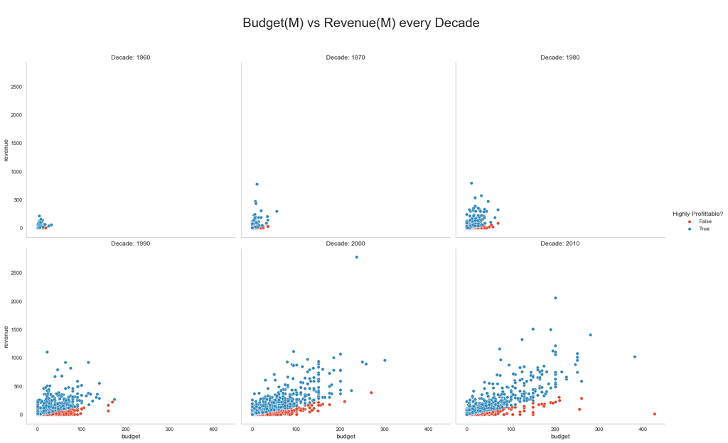

[output not shown]

```python
sns.set_style("whitegrid", {'axes.grid' : False})

g = sns.FacetGrid(movie_every_decade, col='decade', hue= 'Highly Profittable?', col_wrap=3, height = 6,
                 dropna=True)
g= (g.map(plt.scatter, 'budget', 'revenue', edgecolor="w").add_legend())

# Fill the area with fill_between
g = g.set_titles("Decade: {col_name}")
# Add a title for the whole ploT
plt.subplots_adjust(top=0.85)
g = g.fig.suptitle('\nBudget(M) vs Revenue(M) every Decade\n',fontsize =25)
plt.show()
```

#### Each point in the Scatterplot represents a movie title. It's pretty obvious that there are a lot more movies being made every passing decade.

#### Colors in the chart means whather it's the revenue earned is at least 50% above budget or not. (Gross profit>50%)

#### Also, we can see the pattern across the 6 decades that, high budgeted movies seem to be generating more revenue barring a few outliers.

### 7) Find out the Top 5 Movie Genres by Gross Profit every Decade.

```python
movie_every_decade_genres = pd.merge(genres, movie_every_decade , left_on='id', right_on='id', how='left')
movie_every_decade_genres["Gross Profit"] =  movie_every_decade_genres["revenue"] - movie_every_decade_genres["budget"]

movie_every_decade_genres= movie_every_decade_genres.groupby(['decade','genre']).mean().reset_index()
movie_every_decade_genres.head(5)
```

|  | decade | genre | budget | revenue | Gross profit% | Highly Profittable? | Gross Profit |
| --- | --- | --- | --- | --- | --- | --- | --- |
| 0 | 1960 | Action | 2.698630 | 11.835616 | inf | 0.205479 | 9.136986 |
| 1 | 1960 | Adventure | 3.444444 | 21.481481 | 8.825928 | 0.314815 | 18.037037 |
| 2 | 1960 | Animation | 0.266667 | 14.400000 | 53.000000 | 0.066667 | 14.133333 |
| 3 | 1960 | Comedy | 0.787879 | 6.272727 | inf | 0.161616 | 5.484848 |
| 4 | 1960 | Crime | 1.351351 | 8.864865 | inf | 0.297297 | 7.513514 |

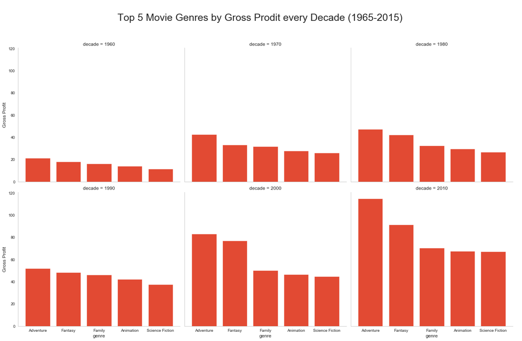

```python
sns.set_style("whitegrid", {'axes.grid' : False})

g = sns.FacetGrid(movie_every_decade_genres.sort_values('Gross Profit',ascending=False).groupby(['decade']).head(5),
                  col='decade',   col_wrap=3, height = 6, dropna=True)
g= (g.map(plt.bar, 'genre', 'Gross Profit', edgecolor="w").add_legend())


plt.subplots_adjust(top=0.85)
g = g.fig.suptitle('\nTop 5 Movie Genres by Gross Prodit every Decade (1965-2015)\n',fontsize =25)
plt.show()
```

##### It's evident from the Analysis that Adventure movies have been the most profittable movie genres every decade. Also, the set of Top 5 movie genres have remained the same over the years.

#### Another interesting insight from the dataset is, Science fiction genres has been closing in on the Animation categories and it could easily surpass the animation genres soon.

## Conclusions

##### 4) The Keywords wordcloud suggests thats there are many movies made by women directors, many moved are made based on Novels and New Your city appears prominately as a keyword in the dataset.

##### 5) Fom the Scatter plot, I found the pattern across the 6 decades that, high budgeted movies seem to be generating more revenues barring a few outliers.

##### 6) The Top 5 Movie Genres by Gross Profit every Decade suggests that Adventure movies have been the most profittable movie genres every decade. Also, the set of Top 5 movie genres have remained the same over the years. Another interesting insight from the dataset is, Science fiction genres has been catching up t the Animation categories and it could easily surpass the animation genres soon..

### Assumptions

I have a made a few assumptions while analyzing the dataset:

###### 1) the dataset includes all the movies in the 1965-2015 time period.

###### 3) Inflation adjusted number changes over time, so, it may look diffferent when the dataset is updated with new movies/ years.

###### 3) It's difficult to determine wheather a movie is proffitable based on the dataset. We can only estimate teh gross profit but, we need more details to get the Net profit because some of the expenses and taxes paid etc may not be included in the budget metric.

## Websites referred for this excercize:

### stackoverflow.com

### pandas.pydata.org

### pandas.pydata.org

### python-graph-gallery.com